# Practical Machine Learning: Peer Assessment

Santos

## Predicting Barbell Lifts

- The Code

### Summary

The goal of this project was to use data from accelerometers on 6 different individuals to predict the way in which individuals performed barbell lifts. The data for this project come from this source: http://groupware.les.inf.puc-rio.br/har. Data was collected from six individuals.

### Cleaning The Data

Here’s a summary of the data:

```
## Observations: 19622
## Variables:
## $ X                        (int) 1, 2, 3, 4, 5, 6, 7, 8, 9, 10, 11, 12...
## $ user_name                (fctr) carlitos, carlitos, carlitos, carlit...
## $ raw_timestamp_part_1     (int) 1323084231, 1323084231, 1323084231, 1...
## $ raw_timestamp_part_2     (int) 788290, 808298, 820366, 120339, 19632...
## $ cvtd_timestamp           (fctr) 05/12/2011 11:23, 05/12/2011 11:23, ...
## $ new_window               (fctr) no, no, no, no, no, no, no, no, no, ...
## $ num_window               (int) 11, 11, 11, 12, 12, 12, 12, 12, 12, 1...
## $ roll_belt                (dbl) 1.41, 1.41, 1.42, 1.48, 1.48, 1.45, 1...
## $ pitch_belt               (dbl) 8.07, 8.07, 8.07, 8.05, 8.07, 8.06, 8...
## $ yaw_belt                 (dbl) -94.4, -94.4, -94.4, -94.4, -94.4, -9...
## $ total_accel_belt         (int) 3, 3, 3, 3, 3, 3, 3, 3, 3, 3, 3, 3, 3...
## $ kurtosis_roll_belt       (dbl) NA, NA, NA, NA, NA, NA, NA, NA, NA, N...
## $ kurtosis_picth_belt      (dbl) NA, NA, NA, NA, NA, NA, NA, NA, NA, N...
```

[output cut: 147 more lines]

```r
## remove columns that have lots of NAs
na_count <- sapply(training, function(y) sum(length(which(is.na(y)))))
training2 <- training[,na_count<0.9]
```

Then, there were a few variables, indexes and timestamps, that also seemed unnecessary.

```r
## remove other columns that don't seem to matter
dropvars <- c("X","raw_timestamp_part_1","raw_timestamp_part_2","cvtd_timestamp","num_window")
training2 <- select(training2, -one_of(dropvars))
```

```r
## Partition the data set
set.seed(333)
trainIndex <- createDataPartition(training2$classe, p=0.6, list=FALSE)
trainSet <- training2[trainIndex,]
testSet <- training2[-trainIndex,]
tCtrl <- trainControl(method="cv", number=5, allowParallel=TRUE)
```

### Analysis

In order to get a feel for which features would have the most impact on the outcome, I made a CART classification tree.

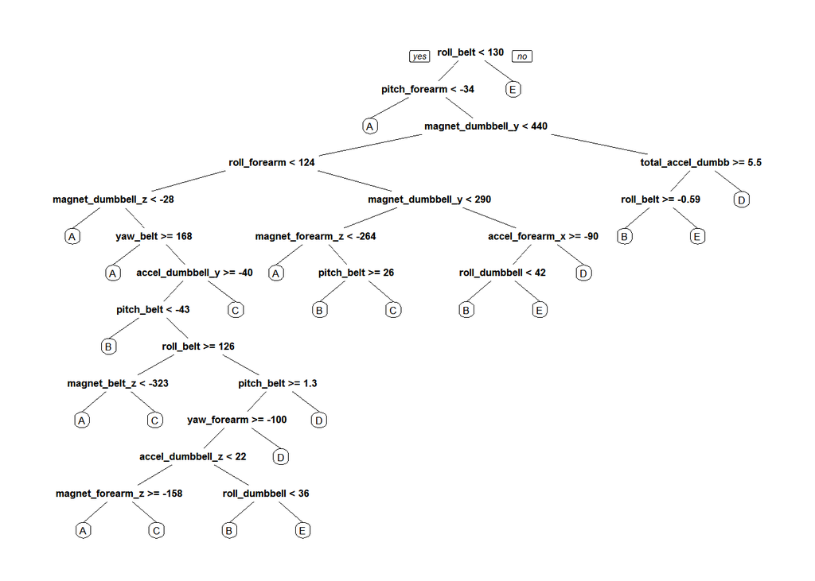

```r
## Make a tree to explore the importance of the features
library(rpart)
library(ggplot2)
treeModel <- rpart(classe ~ ., data=trainSet, method="class")
library(rpart.plot)
prp(treeModel)
```

As can be seen, the roll-belt feature has a strong influence on predicting Class E, and that pitch_forearm has a strong influence on predicting Class A, and so on.

So, then, I made a random forest model with 5-fold cross-validation. I expected that roll-belt and pitch_forearm would be important predictors in this case. The details of the cross-validation procedure are outlined below.

```r
model.1 <- train(classe~., data=trainSet, method="rf", trControl = tCtrl)
model.1
```

```
## Random Forest
##
## 11776 samples
##    54 predictor
##     5 classes: 'A', 'B', 'C', 'D', 'E'
##
## No pre-processing
## Resampling: Cross-Validated (5 fold)
##
## Summary of sample sizes: 9420, 9423, 9420, 9420, 9421
##
## Resampling results across tuning parameters:
##
##   mtry  Accuracy   Kappa      Accuracy SD  Kappa SD
##    2    0.9870081  0.9835639  0.001571950  0.001989712
##   30    0.9887069  0.9857137  0.003568908  0.004516345
##   58    0.9821677  0.9774406  0.003863966  0.004891623
##
## Accuracy was used to select the optimal model using  the largest value.
## The final value used for the model was mtry = 30.
```

```r
model.1$finalModel
```

```
##
## Call:
##  randomForest(x = x, y = y, mtry = param$mtry)
##                Type of random forest: classification
##                      Number of trees: 500
## No. of variables tried at each split: 30
##
##         OOB estimate of  error rate: 0.93%
## Confusion matrix:
##      A    B    C    D    E class.error
## A 3340    4    2    0    2 0.002389486
## B   22 2249    7    1    0 0.013163668
## C    0   14 2033    7    0 0.010223953
## D    0    1   35 1892    2 0.019689119
## E    0    0    3   10 2152 0.006004619
```

The out-of-bag estimate of classification error is 0.93%. That’s pretty good!

```r
varImp(model.1)
```

```
## rf variable importance
##
##   only 20 most important variables shown (out of 58)
##
##                      Overall
## roll_belt             100.00
## pitch_forearm          60.56
## yaw_belt               52.31
## pitch_belt             44.90
## magnet_dumbbell_z      44.86
## magnet_dumbbell_y      41.86
## roll_forearm           41.82
## accel_dumbbell_y       22.60
## roll_dumbbell          20.82
## magnet_dumbbell_x      20.41
## accel_forearm_x        17.90
## magnet_belt_z          17.01
## magnet_belt_y          16.04
## total_accel_dumbbell   15.35
## accel_dumbbell_z       15.08
## magnet_forearm_z       14.17
## gyros_belt_z           12.66
## accel_belt_z           12.50
## yaw_arm                11.51
## magnet_belt_x          11.13
```

The variance Importance values support the initial CART in that roll belt and pitch forearm are the most important variables.

I then predict on the 40% hold-out set.

```r
validate <- predict(model.1,testSet)
confusionMatrix(validate,testSet$classe)
```

```
## Confusion Matrix and Statistics
##
##           Reference
## Prediction    A    B    C    D    E
##          A 2229   16    0    0    0
##          B    2 1498   11    0    1
##          C    1    4 1354   10    1
##          D    0    0    3 1276    7
##          E    0    0    0    0 1433
##
## Overall Statistics
##
##                Accuracy : 0.9929
##                  95% CI : (0.9907, 0.9946)
##     No Information Rate : 0.2845
##     P-Value [Acc > NIR] : < 2.2e-16
##
##                   Kappa : 0.991
##  Mcnemar's Test P-Value : NA
##
## Statistics by Class:
##
##                      Class: A Class: B Class: C Class: D Class: E
## Sensitivity            0.9987   0.9868   0.9898   0.9922   0.9938
## Specificity            0.9971   0.9978   0.9975   0.9985   1.0000
## Pos Pred Value         0.9929   0.9907   0.9883   0.9922   1.0000
## Neg Pred Value         0.9995   0.9968   0.9978   0.9985   0.9986
## Prevalence             0.2845   0.1935   0.1744   0.1639   0.1838
## Detection Rate         0.2841   0.1909   0.1726   0.1626   0.1826
## Detection Prevalence   0.2861   0.1927   0.1746   0.1639   0.1826
## Balanced Accuracy      0.9979   0.9923   0.9936   0.9953   0.9969
```